# Compte rendu TP4 - tests statistiques - ANOVA

Laroussi Labid Bachri, M1 BBS

27-09-2025

```r
library(agricolae)
```

# Analyse de la variance (ANOVA)

Exploration jeu de données

## ANOVA à 1 facteur (une variable qualitative)

```r
resistance <- read.table("resistance.txt", header=T, stringsAsFactors=T); head(resistance) ; tail(resistance)
```

```
##   score lignee
## 1    54  HM008
## 2    50  HM008
## 3    50  HM008
## 4    58  HM008
## 5    57  HM008
## 6    55  HM008
```

```
##    score lignee
## 35    59  HM013
## 36    57  HM013
## 37    53  HM013
## 38    60  HM013
## 39    52  HM013
## 40    55  HM013
```

```r
names(resistance)
```

```
## [1] "score"  "lignee"
```

```r
table(resistance$lignee)
```

```
##
##   A17 DZA45 HM008 HM013
##    10    10    10    10
```

```r
tapply(resistance$score, resistance$lignee , mean )
```

```
##   A17 DZA45 HM008 HM013
##  56.4  61.6  53.6  55.6
```

```r
# va appliquer la fonction mean sur le score et les regrouper par lignees.
tapply(resistance$score, resistance$lignee, summary)
```

```
## $A17
##    Min. 1st Qu.  Median    Mean 3rd Qu.    Max.
##   54.00   55.00   55.50   56.40   57.75   61.00
##
## $DZA45
##    Min. 1st Qu.  Median    Mean 3rd Qu.    Max.
##   58.00   58.25   61.50   61.60   64.50   66.00
##
## $HM008
##    Min. 1st Qu.  Median    Mean 3rd Qu.    Max.
##   50.00   50.25   53.50   53.60   56.50   58.00
##
## $HM013
##    Min. 1st Qu.  Median    Mean 3rd Qu.    Max.
##   52.00   52.25   55.50   55.60   58.50   60.00
```

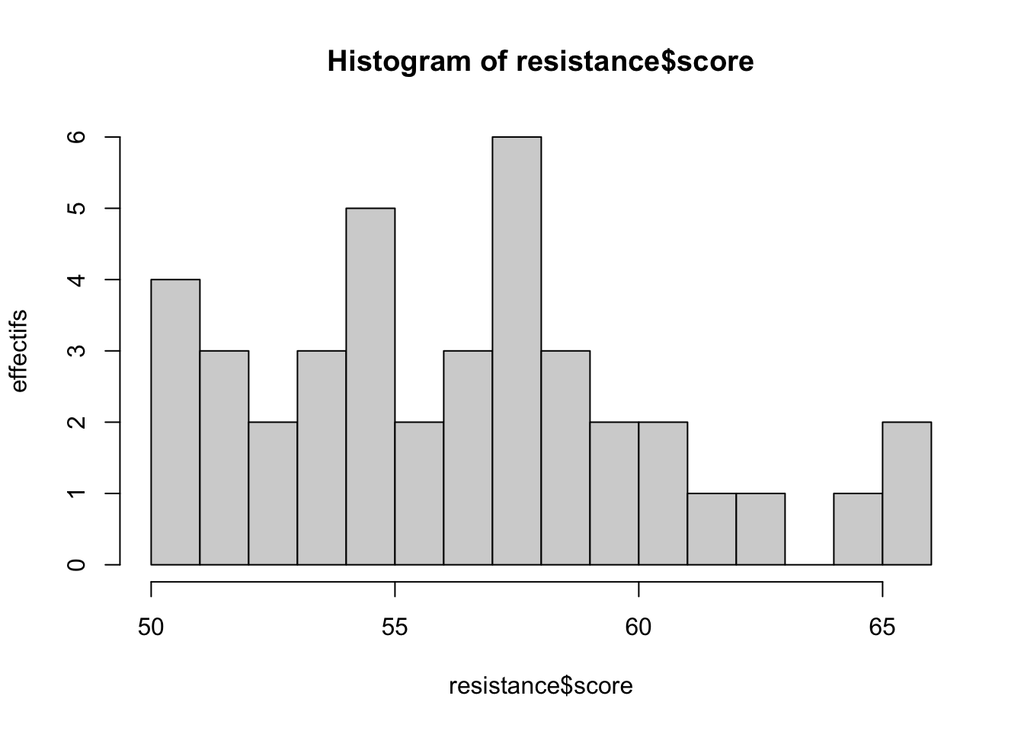

```r
# va appliquer la fonction summary sur le score et les regrouper par lignees.
hist(resistance$score, breaks=15, ylab="effectifs" )
```

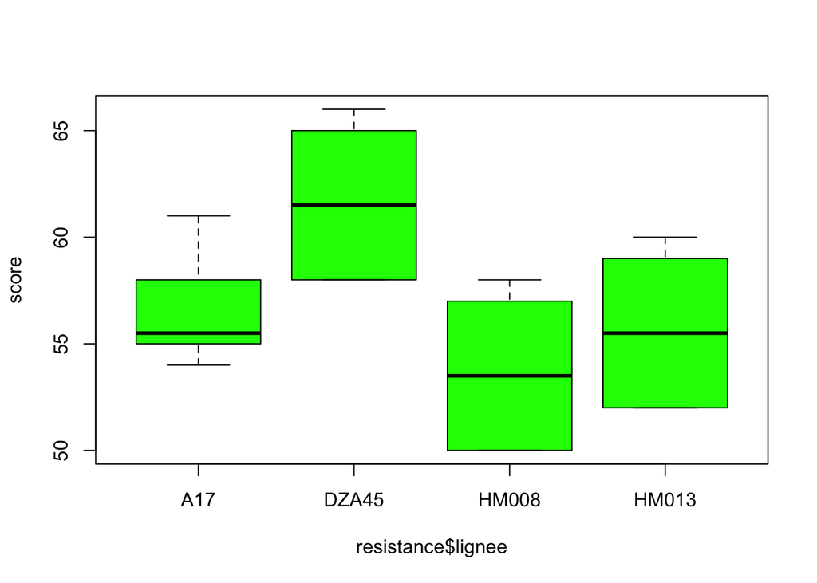

```r
boxplot(resistance$score~resistance$lignee, col="green", ylab="score")
```

## Test d’adéquation à la loi normale (H0 = “les données suivent la loi Normale”)

```r
shapiro.test(resistance$score[resistance$lignee=="HM008"])
```

```
##
##  Shapiro-Wilk normality test
##
## data:  resistance$score[resistance$lignee == "HM008"]
## W = 0.87013, p-value = 0.1003
```

```r
shapiro.test(resistance$score[resistance$lignee=="A17"] )
```

```
##
##  Shapiro-Wilk normality test
##
## data:  resistance$score[resistance$lignee == "A17"]
## W = 0.89716, p-value = 0.2038
```

```r
shapiro.test(resistance$score[resistance$lignee=="DZA45"])
```

```
##
##  Shapiro-Wilk normality test
##
## data:  resistance$score[resistance$lignee == "DZA45"]
## W = 0.87013, p-value = 0.1003
```

```r
shapiro.test(resistance$score[resistance$lignee=="HM013"])
```

```
##
##  Shapiro-Wilk normality test
##
## data:  resistance$score[resistance$lignee == "HM013"]
## W = 0.87013, p-value = 0.1003
```

```r
# Ou on fait tapply
tapply(resistance$score, resistance$lignee , shapiro.test )
```

```
## $A17
##
##  Shapiro-Wilk normality test
##
## data:  X[[i]]
## W = 0.89716, p-value = 0.2038
##
##
## $DZA45
##
##  Shapiro-Wilk normality test
##
## data:  X[[i]]
## W = 0.87013, p-value = 0.1003
##
##
## $HM008
##
##  Shapiro-Wilk normality test
##
## data:  X[[i]]
## W = 0.87013, p-value = 0.1003
##
##
## $HM013
##
##  Shapiro-Wilk normality test
##
## data:  X[[i]]
## W = 0.87013, p-value = 0.1003
```

On observe que les p value sont toutes superieures a 0.05 donc on accpete l’hypothese nulle.

## Test d’homogénéité des variances intra-groupes (H0 : “les variances sont égales”)

```r
bartlett.test(resistance$score~resistance$lignee)
```

```
##
##  Bartlett test of homogeneity of variances
##
## data:  resistance$score by resistance$lignee
## Bartlett's K-squared = 1.4289, df = 3, p-value = 0.6988
```

On trouve une p value de 0.6988. Les groupes ont donc des variances homogènes.

## ANOVA à 1 facteur (le facteur est la variable “resistance$resistance$lignee”) → H0 :“les moyennes des différents groupes sont égales”

```r
res = aov(resistance$score~resistance$lignee) # Test ANOVA

summary(res) # Afficher tableau ANOVA.
```

```
##                   Df Sum Sq Mean Sq F value   Pr(>F)
## resistance$lignee  3  348.8  116.27   12.18 1.18e-05 ***
## Residuals         36  343.6    9.54
## ---
## Signif. codes:  0 '***' 0.001 '**' 0.01 '*' 0.05 '.' 0.1 ' ' 1
```

```r
# Df = degre de liberte
# sum square = somme ecart a la moyenne.

# Aire sous la courbe, p value = 1.18e-5.
```

Toutes les moyennes ne sont pas egales. p value = 1.18e-5.

```r
model.tables(res)
```

```
## Tables of effects
##
##  resistance$lignee
## resistance$lignee
##   A17 DZA45 HM008 HM013
##  -0.4   4.8  -3.2  -1.2
```

```r
tapply(resistance$score , resistance$lignee , mean) - mean(resistance$score) # Differences de la moyenne par rapport a moyenne generale.
```

```
##   A17 DZA45 HM008 HM013
##  -0.4   4.8  -3.2  -1.2
```

```r
t.test(resistance$score[resistance$lignee=="DZA45"], resistance$score[resistance$lignee=="HM013"], var.equal=T)
```

```
##
##  Two Sample t-test
##
## data:  resistance$score[resistance$lignee == "DZA45"] and resistance$score[resistance$lignee == "HM013"]
## t = 4.0575, df = 18, p-value = 0.0007389
## alternative hypothesis: true difference in means is not equal to 0
## 95 percent confidence interval:
##  2.893286 9.106714
## sample estimates:
## mean of x mean of y
##      61.6      55.6
```

```r
t.test(resistance$score[resistance$lignee=="DZA45"], resistance$score[resistance$lignee=="HM008"], var.equal=T)
```

```
##
##  Two Sample t-test
##
## data:  resistance$score[resistance$lignee == "DZA45"] and resistance$score[resistance$lignee == "HM008"]
## t = 5.41, df = 18, p-value = 3.856e-05
## alternative hypothesis: true difference in means is not equal to 0
## 95 percent confidence interval:
##   4.893286 11.106714
## sample estimates:
## mean of x mean of y
##      61.6      53.6
```

```r
t.test(resistance$score[resistance$lignee=="DZA45"], resistance$score[resistance$lignee=="A17"], var.equal=T)
```

```
##
##  Two Sample t-test
##
## data:  resistance$score[resistance$lignee == "DZA45"] and resistance$score[resistance$lignee == "A17"]
## t = 4.0716, df = 18, p-value = 0.0007161
## alternative hypothesis: true difference in means is not equal to 0
## 95 percent confidence interval:
##  2.516808 7.883192
## sample estimates:
## mean of x mean of y
##      61.6      56.4
```

```r
t.test(resistance$score[resistance$lignee=="A17"], resistance$score[resistance$lignee=="HM013"], var.equal=T)
```

```
##
##  Two Sample t-test
##
## data:  resistance$score[resistance$lignee == "A17"] and resistance$score[resistance$lignee == "HM013"]
## t = 0.62639, df = 18, p-value = 0.5389
## alternative hypothesis: true difference in means is not equal to 0
## 95 percent confidence interval:
##  -1.883192  3.483192
## sample estimates:
## mean of x mean of y
##      56.4      55.6
```

```r
t.test(resistance$score[resistance$lignee=="HM008"], resistance$score[resistance$lignee=="HM013"], var.equal=T)
```

```
##
##  Two Sample t-test
##
## data:  resistance$score[resistance$lignee == "HM008"] and resistance$score[resistance$lignee == "HM013"]
## t = -1.3525, df = 18, p-value = 0.193
## alternative hypothesis: true difference in means is not equal to 0
## 95 percent confidence interval:
##  -5.106714  1.106714
## sample estimates:
## mean of x mean of y
##      53.6      55.6
```

```r
t.test(resistance$score[resistance$lignee=="A17"], resistance$score[resistance$lignee=="HM008"], var.equal=T)
```

```
##
##  Two Sample t-test
##
## data:  resistance$score[resistance$lignee == "A17"] and resistance$score[resistance$lignee == "HM008"]
## t = 2.1924, df = 18, p-value = 0.04174
## alternative hypothesis: true difference in means is not equal to 0
## 95 percent confidence interval:
##  0.1168082 5.4831918
## sample estimates:
## mean of x mean of y
##      56.4      53.6
```

```r
pairwise.t.test(resistance$score , resistance$lignee , pool.sd=F, p.adjust.method = "bonferroni" , var.equal=T)
```

```
##
##  Pairwise comparisons using t tests with non-pooled SD
##
## data:  resistance$score and resistance$lignee
##
##       A17     DZA45   HM008
## DZA45 0.00430 -       -
## HM008 0.25042 0.00023 -
## HM013 1.00000 0.00443 1.00000
##
## P value adjustment method: bonferroni
```

```r
# il va faire les tests 2 a 2

# bonferroni va multipliler les p values et diviser le seuil par le nombre de tests.
```

On trouve une difference significative du score entre DZA45 et HM013. On trouve une difference significative du score entre DZA45 et HM008. On trouve une difference significative du score entre DZA45 et A17.